# Title

#### The event types were modified in the following order:

-“tornad” = “TORNADO”  
-“spout” = “TORNADO”  
-“thun.*orm" =“THUNDERSTORM”  
-“tstm” = “THUNDERSTORM”  
-“snow” = “WINTER WEATHER”  
-“blizzard” = “WINTER WEATHER”  
-“hail” = “HAIL”  
-“rain” = “RAIN”  
-“precip” = “RAIN”  
-“hurricane” = “HURRICANE”  
-“tropical.*storm" = “TROPICAL STORM”  
-“flood” = “FLOOD”  
-“fld” =“FLOOD”  
-“fire” = “FIRE”  
-“lightn” = “LIGHTNING”  
-“wind” = “OTHER WIND”  
-“cold” = “WINTER WEATHER”  
-“heat” = “HEAT”  
-“storm surge” = “STORM SURGE”  
-“surf” = “OTHER WATER EVENT”  
-“rip” = “OTHER WATER EVENT”  
-“tid” = “OTHER WATER EVENT”  
-“chill” = “WINTER WEATHER”  
-“drought” = “DRYNESS”  
-“wint” = “WINTER WEATHER”  
-“dust” = “DUST”  
-“fog” =“FOG”  
-“freez” = “WINTER WEATHER”  
-“frost” = “WINTER WEATHER”  
-“ice” = “WINTER WEATHER”  
-“funn” = “TORNADO”  
-“warm” = “HEAT”  
-“depress” = “HURRICANE”  
-“sleet” = “WINTER WEATHER”  
-“dry” = “DRYNESS”  
-“ice” = “WINTER WEATHER”  
-“icy” = “WINTER WEATHER”  
-“cool” = “HEAT”  
-“hot” = “WINTER WEATHER”  
-“seas” = “OTHER WATER EVENT”  
-“landsl” = “LANDSLIDE”  
-“mudsl” = “LANDSLIDE”  
-“stream” = “OTHER WATER EVENT”  
-“water” = “OTHER WATER EVENT”  
-“high” = “HEAT”

```r
stormdata20$EvType <- as.character(stormdata20$EVTYPE)
stormdata20$EvType[grepl("tornad", stormdata20$EvType, ignore.case = TRUE)]          <- "TORNADO"
stormdata20$EvType[grepl("spout", stormdata20$EvType, ignore.case = TRUE)]           <- "TORNADO"
stormdata20$EvType[grepl("thun.*orm", stormdata20$EvType, ignore.case = TRUE)]       <- "THUNDERSTORM"
stormdata20$EvType[grepl("tstm", stormdata20$EvType, ignore.case = TRUE)]            <- "THUNDERSTORM"
stormdata20$EvType[grepl("snow", stormdata20$EvType, ignore.case = TRUE)]            <- "WINTER WEATHER"
stormdata20$EvType[grepl("blizzard", stormdata20$EvType, ignore.case = TRUE)]        <- "WINTER WEATHER"
stormdata20$EvType[grepl("hail", stormdata20$EvType, ignore.case = TRUE)]            <- "HAIL"
stormdata20$EvType[grepl("rain", stormdata20$EvType, ignore.case = TRUE)]            <- "RAIN"
stormdata20$EvType[grepl("precip", stormdata20$EvType, ignore.case = TRUE)]          <- "RAIN"
stormdata20$EvType[grepl("hurricane", stormdata20$EvType, ignore.case = TRUE)]       <- "HURRICANE"
stormdata20$EvType[grepl("tropical.*storm", stormdata20$EvType, ignore.case = TRUE)] <- "TROPICAL STORM"
stormdata20$EvType[grepl("flood", stormdata20$EvType, ignore.case = TRUE)]           <- "FLOOD"
stormdata20$EvType[grepl("fld", stormdata20$EvType, ignore.case = TRUE)]             <- "FLOOD"
stormdata20$EvType[grepl("fire", stormdata20$EvType, ignore.case = TRUE)]            <- "FIRE"
stormdata20$EvType[grepl("lightn", stormdata20$EvType, ignore.case = TRUE)]          <- "LIGHTNING"
stormdata20$EvType[grepl("wind", stormdata20$EvType, ignore.case = TRUE)]            <- "OTHER WIND"
stormdata20$EvType[grepl("cold", stormdata20$EvType, ignore.case = TRUE)]            <- "WINTER WEATHER"
stormdata20$EvType[grepl("heat", stormdata20$EvType, ignore.case = TRUE)]            <- "HEAT"
stormdata20$EvType[grepl("storm surge", stormdata20$EvType, ignore.case = TRUE)]     <- "STORM SURGE"
stormdata20$EvType[grepl("surf", stormdata20$EvType, ignore.case = TRUE)]            <- "OTHER WATER EVENT"
stormdata20$EvType[grepl("rip", stormdata20$EvType, ignore.case = TRUE)]             <- "OTHER WATER EVENT"
stormdata20$EvType[grepl("tid", stormdata20$EvType, ignore.case = TRUE)]             <- "OTHER WATER EVENT"
stormdata20$EvType[grepl("chill", stormdata20$EvType, ignore.case = TRUE)]           <- "WINTER WEATHER"
stormdata20$EvType[grepl("drought", stormdata20$EvType, ignore.case = TRUE)]         <- "DRYNESS"
stormdata20$EvType[grepl("wint", stormdata20$EvType, ignore.case = TRUE)]            <- "WINTER WEATHER"
stormdata20$EvType[grepl("dust", stormdata20$EvType, ignore.case = TRUE)]            <- "DUST"
stormdata20$EvType[grepl("fog", stormdata20$EvType, ignore.case = TRUE)]             <- "FOG"
stormdata20$EvType[grepl("freez", stormdata20$EvType, ignore.case = TRUE)]           <- "WINTER WEATHER"
stormdata20$EvType[grepl("frost", stormdata20$EvType, ignore.case = TRUE)]           <- "WINTER WEATHER"
stormdata20$EvType[grepl("ice", stormdata20$EvType, ignore.case = TRUE)]             <- "WINTER WEATHER"
stormdata20$EvType[grepl("funn", stormdata20$EvType, ignore.case = TRUE)]            <- "TORNADO"
stormdata20$EvType[grepl("warm", stormdata20$EvType, ignore.case = TRUE)]            <- "HEAT"
stormdata20$EvType[grepl("depress", stormdata20$EvType, ignore.case = TRUE)]         <- "HURRICANE"
stormdata20$EvType[grepl("sleet", stormdata20$EvType, ignore.case = TRUE)]           <- "WINTER WEATHER"
stormdata20$EvType[grepl("dry", stormdata20$EvType, ignore.case = TRUE)]             <- "DRYNESS"
stormdata20$EvType[grepl("ice", stormdata20$EvType, ignore.case = TRUE)]             <- "WINTER WEATHER"
stormdata20$EvType[grepl("icy", stormdata20$EvType, ignore.case = TRUE)]             <- "WINTER WEATHER"
stormdata20$EvType[grepl("cool", stormdata20$EvType, ignore.case = TRUE)]             <- "HEAT"
stormdata20$EvType[grepl("hot", stormdata20$EvType, ignore.case = TRUE)]             <- "WINTER WEATHER"
stormdata20$EvType[grepl("seas", stormdata20$EvType, ignore.case = TRUE)]             <- "OTHER WATER EVENT"
stormdata20$EvType[grepl("landsl", stormdata20$EvType, ignore.case = TRUE)]             <- "LANDSLIDE"
stormdata20$EvType[grepl("mudsl", stormdata20$EvType, ignore.case = TRUE)]             <- "LANDSLIDE"
stormdata20$EvType[grepl("stream", stormdata20$EvType, ignore.case = TRUE)]             <- "OTHER WATER EVENT"
stormdata20$EvType[grepl("water", stormdata20$EvType, ignore.case = TRUE)]             <- "OTHER WATER EVENT"
stormdata20$EvType[grepl("high", stormdata20$EvType, ignore.case = TRUE)]             <- "HEAT"
stormdata20$EvType <- as.factor(stormdata20$EvType)
```

#### Recreate New List of Top Events For Last 20 Years Using Merged Event Types

Below we have created a new list of top events based upon event frequency. This seems like an accurate and satisfactory consolidation of events by type.

```r
NewEventSum <- ddply(stormdata20, .(EvType) , summarise , Count = length(EvType))
NewEventSumSort <- NewEventSum[order(-NewEventSum$Count) , ]
NewEventSumSort[1:25, ]
```

```
##                 EvType  Count
## 151       THUNDERSTORM 252297
## 33                HAIL 233138
## 27               FLOOD  86086
## 172     WINTER WEATHER  44776
## 152            TORNADO  38171
## 67          OTHER WIND  28114
## 47           LIGHTNING  15760
## 68                RAIN  12288
## 25                FIRE   4240
## 34                HEAT   3020
## 20             DRYNESS   2775
## 66   OTHER WATER EVENT   2172
## 28                 FOG   1882
## 154     TROPICAL STORM    697
## 44           LANDSLIDE    637
## 21                DUST    586
## 83         STORM SURGE    409
## 5            AVALANCHE    386
## 39           HURRICANE    348
## 65               OTHER     48
## 150 Temperature record     43
## 30               GLAZE     32
## 162       VOLCANIC ASH     22
## 79              SEICHE     21
## 155            TSUNAMI     20
```

## DP4: Create Fatalities/Injuries Datasets For Analysis

#### Pull together final dataset for fatalities/injuries analysis

#### Limit dataset to events where either injuries of fatalities happened.

```r
stormdata20InjFat<-stormdata20[(stormdata20$FATALITIES > 0)|(stormdata20$INJURIES > 0), ]
```

#### Pull the data needed for analysis of injuries and fatalities.

```r
stormdata20InjFat <- subset(stormdata20InjFat, select=c(EvType, INJURIES, FATALITIES, BeginYear))
stormFinalCC <- stormdata20InjFat [complete.cases(stormdata20),]
```

## DP5: Subset the Crop/Property Data

As can be seen below, the property/crop damages and fatalities/injuries data have significantly different amounts of data, and since there is much more cleaning left to do, it makes sense to subset the data since we will be looking at these separately.

```r
length(stormdata20$CROPDMG[stormdata20$CROPDMG > 0 ])
```

```
## [1] 22099
```

```r
length(stormdata20$PROPDMG[stormdata20$PROPDMG > 0 ])
```

```
## [1] 214382
```

```r
length(stormdata20$FATALITIES[stormdata20$FATALITIES > 0 ])
```

```
## [1] 5711
```

```r
length(stormdata20$INJURIES[stormdata20$INJURIES > 0 ])
```

```
## [1] 11065
```

```r
length(stormdata20$CROPDMG[stormdata20$CROPDMG == 0 ])
```

```
## [1] 706173
```

```r
length(stormdata20$PROPDMG[stormdata20$PROPDMG == 0 ])
```

```
## [1] 513890
```

```r
length(stormdata20$FATALITIES[stormdata20$FATALITIES == 0 ])
```

```
## [1] 722561
```

```r
length(stormdata20$INJURIES[stormdata20$INJURIES == 0 ])
```

```
## [1] 717207
```

#### Subset the Property/Crop Damage Data

```r
TGSAll <- subset(stormdata20, select=c(EvType, PROPDMG, PROPDMGEXP, CROPDMG, CROPDMGEXP, BeginDate, BeginYear, STATE))
```

#### Clean Property/Crop data and take a first look

```r
summary(TGSAll$PROPDMG)
```

```
##    Min. 1st Qu.  Median    Mean 3rd Qu.    Max.
##    0.00    0.00    0.00   12.54    1.28 5000.00
```

```r
unique(TGSAll$PROPDMGEXP)
```

```
##  [1] ""  "M" "K" "B" "m" "+" "0" "5" "6" "?" "4" "2" "3" "h" "7" "H" "-"
## [18] "1" "8"
```

```r
summary(TGSAll$CROPDMG)
```

```
##    Min. 1st Qu.  Median    Mean 3rd Qu.    Max.
##   0.000   0.000   0.000   1.892   0.000 990.000
```

```r
unique(TGSAll$CROPDMGEXP)
```

```
## [1] ""  "M" "K" "m" "B" "?" "0" "k" "2"
```

#### Lots of data to clean. Start with removing cases where there was no recorded crop or Property losses. This results in 500,000 less rows.

```r
str(TGSAll)
```

```
## 'data.frame':    728272 obs. of  8 variables:
##  $ EvType    : Factor w/ 173 levels "?","ABNORMALLY WET",..: 151 151 151 151 151 151 151 151 151 151 ...
##  $ PROPDMG   : num  0 0 0 0 0 0 0 0 0 0 ...
##  $ PROPDMGEXP: chr  "" "" "" "" ...
##  $ CROPDMG   : num  0 0 0 0 0 0 0 0 0 0 ...
##  $ CROPDMGEXP: chr  "" "" "" "" ...
##  $ BeginDate : Date, format: "1992-01-13" "1992-01-13" ...
##  $ BeginYear : Factor w/ 62 levels "1950","1951",..: 43 43 43 43 43 43 43 43 43 43 ...
##  $ STATE     : chr  "AL" "AL" "AL" "AL" ...
```

```r
TGS<-TGSAll[(TGSAll$PROPDMG > 0)|(TGSAll$CROPDMG > 0), ]
str(TGS)
```

```
## 'data.frame':    220239 obs. of  8 variables:
##  $ EvType    : Factor w/ 173 levels "?","ABNORMALLY WET",..: 152 152 152 152 152 152 152 152 152 152 ...
##  $ PROPDMG   : num  2.5 250 250 25 25 250 250 250 2.5 25 ...
##  $ PROPDMGEXP: chr  "M" "K" "K" "K" ...
##  $ CROPDMG   : num  0 0 0 0 0 0 0 0 0 0 ...
##  $ CROPDMGEXP: chr  "" "" "" "" ...
##  $ BeginDate : Date, format: "1992-03-09" "1992-03-10" ...
##  $ BeginYear : Factor w/ 62 levels "1950","1951",..: 43 43 43 43 43 43 43 43 43 43 ...
##  $ STATE     : chr  "AL" "AL" "AL" "AL" ...
```

#### Replace Property Damage Exponent bad data with NA’s and replace exponents with appropriate multiplyer so that damage and exp columns can easily be multiplied to get net damage.

```r
TGS$PropDmgExp <- TGS$PROPDMGEXP
TGS$PropDmgExp<-gsub(pattern="1",     replacement="1", TGS$PropDmgExp)
TGS$PropDmgExp<-gsub(pattern="2",     replacement="10", TGS$PropDmgExp)
TGS$PropDmgExp<-gsub(pattern="H|h|3", replacement="100", TGS$PropDmgExp)
TGS$PropDmgExp<-gsub(pattern="K|4",   replacement="1000", TGS$PropDmgExp)
TGS$PropDmgExp<-gsub(pattern="5",     replacement="10000", TGS$PropDmgExp)
TGS$PropDmgExp<-gsub(pattern="6",     replacement="100000", TGS$PropDmgExp)
TGS$PropDmgExp<-gsub(pattern="M|m|7", replacement="1000000", TGS$PropDmgExp)
TGS$PropDmgExp<-gsub(pattern="8",     replacement="10000000", TGS$PropDmgExp)
TGS$PropDmgExp<-gsub(pattern="B",     replacement="100000000", TGS$PropDmgExp)
TGS$PropDmgExp<-gsub(pattern="[[:punct:]]", replacement="NA", TGS$PropDmgExp)
TGS$PropDmgExp<-as.numeric(TGS$PropDmgExp)
```

#### Multiply Property damage and exp to get net property damage

```r
TGS$PropDmgTotal<- TGS$PROPDMG * TGS$PropDmgExp
```

#### Replace Crop Damage Exponent bad data with NA’s and replace exponents with appropriate multiplyer so that damage and exp columns can easily be multiplied to get net damage.

```r
TGS$CropDmgExp <- TGS$CROPDMGEXP
TGS$CropDmgExp<-gsub(pattern="1",     replacement="1", TGS$CropDmgExp)
TGS$CropDmgExp<-gsub(pattern="2",     replacement="10", TGS$CropDmgExp)
TGS$CropDmgExp<-gsub(pattern="H|h|3", replacement="100", TGS$CropDmgExp)
TGS$CropDmgExp<-gsub(pattern="K|4",   replacement="1000", TGS$CropDmgExp)
TGS$CropDmgExp<-gsub(pattern="5",     replacement="10000", TGS$CropDmgExp)
TGS$CropDmgExp<-gsub(pattern="6",     replacement="100000", TGS$CropDmgExp)
TGS$CropDmgExp<-gsub(pattern="M|m|7", replacement="1000000", TGS$CropDmgExp)
TGS$CropDmgExp<-gsub(pattern="8",     replacement="10000000", TGS$CropDmgExp)
TGS$CropDmgExp<-gsub(pattern="B",     replacement="100000000", TGS$CropDmgExp)
TGS$CropDmgExp<-gsub(pattern="[[:punct:]]", replacement="NA", TGS$CropDmgExp)
TGS$CropDmgExp<-as.numeric(TGS$CropDmgExp)
```

#### Multiply crop damage and exp to get net damage

```r
TGS$CropDmgTotal<- TGS$CROPDMG * (TGS$CropDmgExp)
```

#### Pull together final dataset for crop/property damage analysis

```r
TGSFinal <- subset(TGS, select=c(EvType, PropDmgTotal, CropDmgTotal, BeginYear))
TGSFinalCC <- TGSFinal [complete.cases(TGSFinal),]
```

## DP6: Pull Together Data for plots

#### Fatality/Injury Data for plots

```r
FatalityPlot <- aggregate(FATALITIES ~ EvType, data = stormdata20InjFat, FUN = sum)
InjuryPlot <- aggregate(INJURIES ~ EvType, data = stormdata20InjFat, FUN = sum)
Top15Injury <- head(InjuryPlot[order(InjuryPlot$INJURIES, decreasing = T), ], 15)
Top15Fatality <- head(FatalityPlot[order(FatalityPlot$FATALITIES, decreasing = T), ], 15)
```

#### Property/Crop Data for plots

```r
PropertyPlot <- aggregate(PropDmgTotal ~ EvType, data = TGS, FUN = sum)
Top15Property <- head(PropertyPlot[order(PropertyPlot$PropDmgTotal, decreasing = T), ], 15)
CropPlot <- aggregate(CropDmgTotal ~ EvType, data = TGS, FUN = sum)
Top15Crop <- head(CropPlot[order(CropPlot$CropDmgTotal, decreasing = T), ], 15)
```

# Results

## Storm Event Caused Fatalities/Injuries

### Fatalities & Injuries by Event Charts

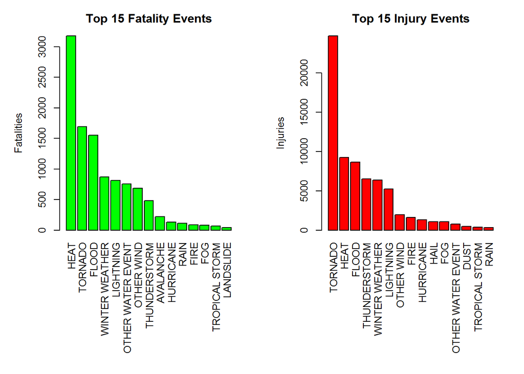

```r
par(mfrow = c(1, 2), mar = c(12, 5, 3, 2), mgp = c(3, 1, 0), cex = 0.8, las = 3)
ylim <- c(0, max(Top15Fatality$FATALITIES))
FatalPlot <- barplot(Top15Fatality$FATALITIES, names.arg = Top15Fatality$EvType, col = 'green',
main = 'Top 15 Fatality Events', ylab = 'Fatalities', ylim = ylim)
ylim <- c(0, max(Top15Injury$INJURIES))
InjuryPlot <- barplot(Top15Injury$INJURIES, names.arg = Top15Injury$EvType, col = 'red',
main = 'Top 15 Injury Events', ylab = 'Injuries', ylim = ylim)
```

## Storm Event Caused PRoperty/Crop Damage

As we see below, flood is the leading cause of property damage and the second leading cause of crop damage. Hurricane events were the third leading cause of both property and crop damage. Interestingly, dryness is the leading cause of crop damage but does not make the top 10 list of events causing the most property damage. Hail was a top 5 cause of both property and crop damage. Property impact of storm damage on property had been much more significant compared to crop damage, causing several times more damage.

### Property & Crop Damage by Event Charts

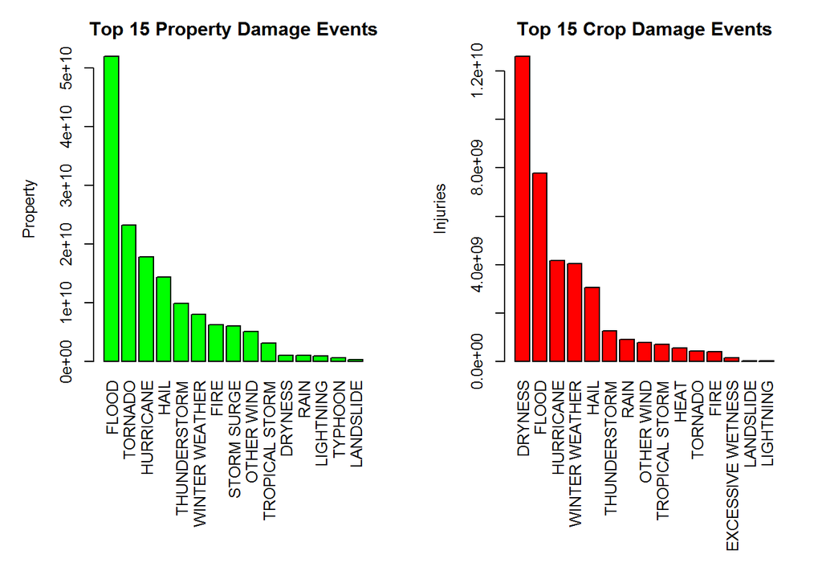

```r
par(mfrow = c(1, 2), mar = c(12, 5, 3, 2), mgp = c(3, 1, 0), cex = 0.8, las = 3)
ylim <- c(0, max(Top15Property$PropDmgTotal))
PropertyPlot <- barplot(Top15Property$PropDmgTotal, names.arg = Top15Property$EvType, col = 'green',
main = 'Top 15 Property Damage Events', ylab = 'Property', ylim = ylim)
ylim <- c(0, max(Top15Crop$CropDmgTotal))
InjuryPlot <- barplot(Top15Crop$CropDmgTotal, names.arg = Top15Crop$EvType, col = 'red',
main = 'Top 15 Crop Damage Events', ylab = 'Injuries', ylim = ylim)
```